# Case Study: Gene Set Enrichment Analysis (Human Data Set)

Alejandro Reyes and Keegan Korthauer

October 30, 2018

# 1 Summary

The objective of this document is to compare different methods for multiple testing correction in the context of Gene Set Enrichment Analysis (GSEA). We use RNA-seq data consisting of cortex and cerebellum samples of a subset of the GTEx individuals. Shortly, samples were downloaded using the *Short Read Archive Toolkit* and mapped to the human reference genome version GRCh38 using *STAR v2.4.2a*. *htseq-count* was used to tabulate the number of uniquely mapping reads for each gene. We used the `DESeq2` package to format the data into a `DESeqDataSet` object.

We use the `fgsea` Bioconductor package to implement the GSEA method. This is a Functional Class Scoring approach, which does not require setting an arbitrary threshold for Differential Expression, but instead relies on the gene’s rank (here we rank by DESeq2 test statistic).

# 2 Workspace Setup

```r
library(dplyr)
```

```r
library(ggplot2)
library(scales)
library(DESeq2)
library(EnsDb.Hsapiens.v86)
library(biomaRt)
library(fgsea)
## load helper functions
for (f in list.files("../R", "\\.(r|R)$", full.names = TRUE)) {
    source(f)
}

## project data/results folders
datdir <- "data"
resdir <- "results"
sbdir <- "../../results/GSEA"
dir.create(datdir, showWarnings = FALSE)
dir.create(resdir, showWarnings = FALSE)
dir.create(sbdir, showWarnings = FALSE)

## intermediary files we create below
count_file <- file.path(datdir, "human-counts.rds")
deseq_file <- file.path(datdir, "human-deseq.rds")
goset_file <- file.path(datdir, "human-gosets.rds")
result_file <- file.path(resdir, "human-results.rds")
bench_file <- file.path(sbdir, "human-benchmark.rds")
bench_file_uninf <- file.path(sbdir, "human-uninf-benchmark.rds")
```

# 3 Data Preparation

We download the *DESeqDataSet* from zenodo, if not present locally, and modify the design to test for differences in gene expression between cerebellums and cortex.

```r
if (!file.exists(count_file)) {
    download.file("https://zenodo.org/record/1475409/files/gsea-human-counts.rds?download=1",
                  destfile = count_file)
}
dsdObject <- readRDS(count_file)
design( dsdObject ) <- ~ tissue
```

To keep running times short, we only perform differential tesing on protein coding genes, as specified in Ensembl release 86.

```r
gnType <- genes(EnsDb.Hsapiens.v86, column = "gene_biotype")
protGenes <- gnType$gene_id[gnType$gene_biotype == "protein_coding"]
dsdObject <- dsdObject[rownames(dsdObject) %in% protGenes, ]
```

# 4 Data Analysis

## 4.1 Enrichment Analysis

Next, we run DESeq2 to retrieve a list of differentially expressed genes at a FDR of 10%.

```r
if (!file.exists(deseq_file)) {
    dsdObject <- DESeq(dsdObject)
    res <- results(dsdObject, independentFiltering = FALSE)
    saveRDS(res, file = deseq_file)
} else {
    res <- readRDS(deseq_file)
}

genes <- as.numeric(res$padj < 0.1)
names(genes) <- rownames(res)
sum(genes, na.rm=TRUE)
```

```
## [1] 9853
```

Next we’ll use the biomaRt package to download and associate GO annotations for each gene.

```r
if (!file.exists(goset_file)) {
    mart <- useMart("ensembl", "hsapiens_gene_ensembl")
    goSets <- getBM(c("ensembl_gene_id", "go_id"), mart = mart,
                    filters = "ensembl_gene_id", values = rownames(res))
    goSets <- goSets[!nchar( goSets$go_id ) == 0, ]
    goSets <- with(goSets, split(go_id, ensembl_gene_id))
    saveRDS(goSets, file = goset_file)
} else {
    goSets <- readRDS(goset_file)
}
```

Now we use the `fgsea` package to perform the gene set enrichment analysis and obtain a enrichment p-value for each pathway.

```r
# invert the list so each item is a pathway instead of a gene
goSets <- split(rep(names(goSets), lengths(goSets)), unlist(goSets))
stats <- res$stat
names(stats) <- rownames(res)
stats <- stats[!is.na(stats)]

if (!file.exists(result_file)) {
  goRes <- fgsea(goSets,
                  stats,
                  nperm=10000,
                  maxSize=500,
                  minSize=5)
  saveRDS(goRes, file = result_file)
} else {
  goRes <- readRDS(result_file)
}
```

Add a random (uninformative covariate) to the dataset.

```r
## Add random (uninformative) covariate
set.seed(66778)
goRes$rand_covar <- rnorm(nrow(goRes))
```

## 4.2 Covariate Diagnostics

Here, we want to check whether the size of the gene set is actually informative and independent under the null.

### 4.2.1 Gene Set Size

We will explore whether the size of the gene set can be used as a covariate for modern multiple-testing correction methods in the context of GSEA. In the plot below, the log10 of the p-values is plotted as a function of the size of the gene set. There is a pattern in which gene sets with a higher number of genes tend to have smaller p-values, which is indicative that gene set size is an informative covariate.

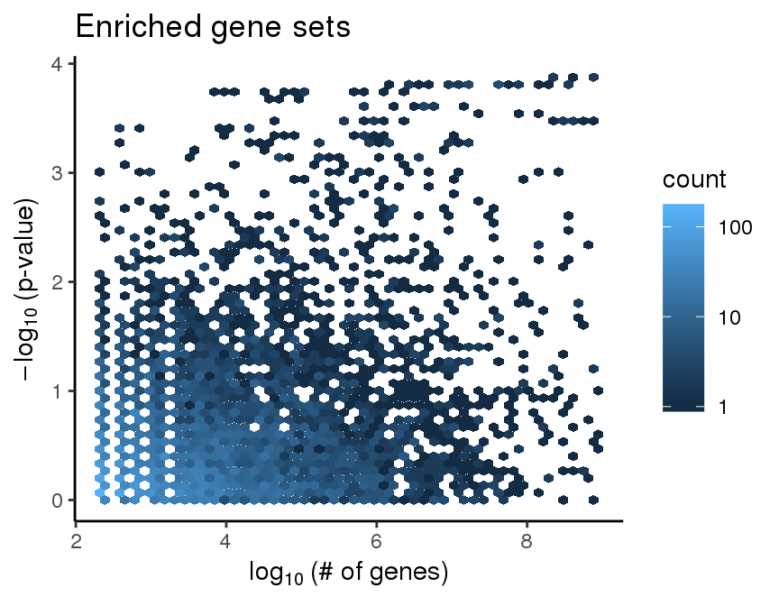

```r
rank_scatter(dat = goRes, pval = "pval",
              covariate = "size", bins = 50, funx = log2,
              funfill = log10_trans()) +
    ggtitle("Enriched gene sets") +
    xlab(expression(log[10]~"(# of genes)")) +
    ylab(expression(-log[10]~"(p-value)") )
```

We can also explore if the covariate seems to be independent under the null.

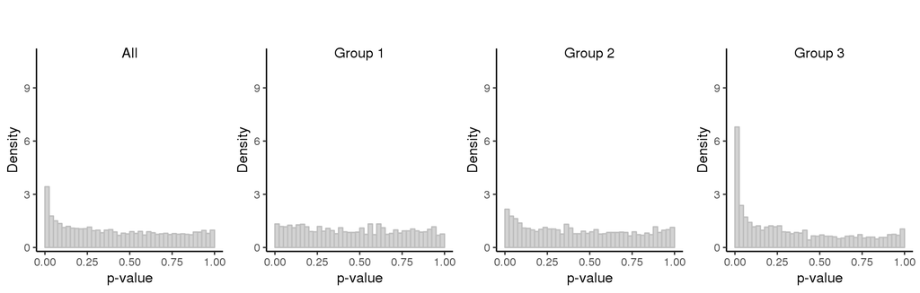

```r
strat_hist(goRes, pval="pval", covariate="size", maxy=11)
```

### 4.2.2 Random

We will explore whether the random covariate can be used as a covariate for modern multiple-testing correction methods in the context of GSEA. In the plot below, the log10 of the p-values is plotted as a function of the random covariate. This covariate looks independent of the p-values.

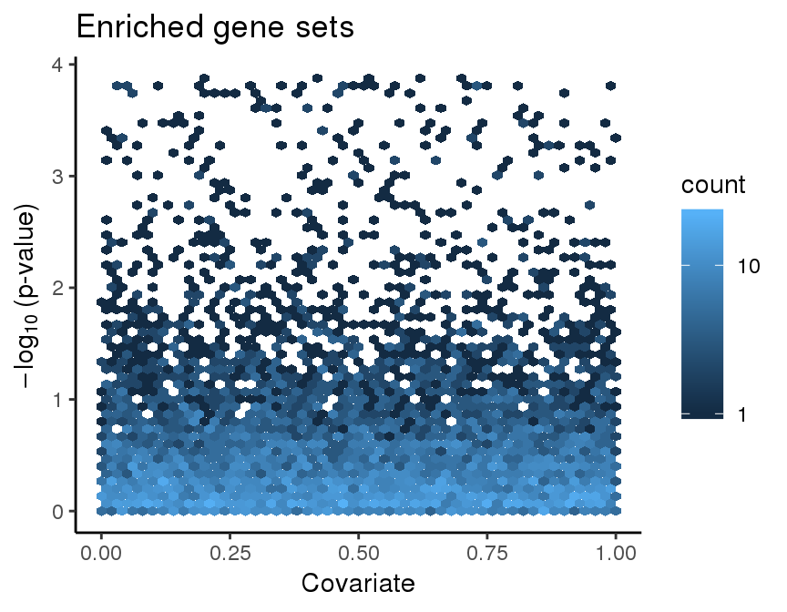

```r
rank_scatter(dat = goRes, pval = "pval",
              covariate = "rand_covar", bins = 50,
              funfill = log10_trans()) +
    ggtitle("Enriched gene sets") +
    ylab(expression(-log[10]~"(p-value)") )
```

We can also explore if the covariate seems to be independent under the null.

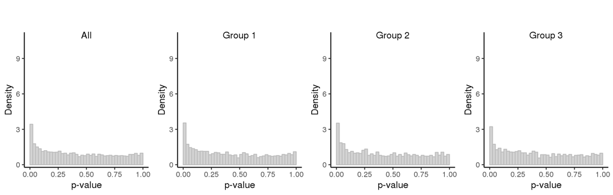

```r
strat_hist(goRes, pval="pval", covariate="rand_covar", maxy=11)
```

## 4.3 Multiple-Testing Correction

We then execute the benchDesign and generate a *SummarizedBenchmark* object containing multiple-testing corrections using several methods.

```r
## rename columns and prepare for benchmarking
res <- dplyr:::select(goRes, c("pval", "size", "rand_covar")) %>%
    dplyr:::rename(ind_covariate = size)

## generate default BenchDesign
bd <- initializeBenchDesign()
```

We don’t include `ashq`, `fdrreg-e` and `fdrreg-t` from the analysis because the necessary assumptions are not met in the current case study. Namely, effect sizes and standard errors are not available for ASH, and the test statistics are not normally distributed under the null and alternative, as required by Scott’s FDR regression methods.

```r
if (!file.exists(bench_file)) {
  sGSEA <- buildBench(bd, res, ftCols = "ind_covariate")
  saveRDS(sGSEA, file = bench_file)
} else {
  sGSEA <- readRDS(bench_file)
}
```

We’ll also compare the results to an uninformative (random) covariate.

```r
if (!file.exists(bench_file_uninf)) {
  res$ind_covariate <- res$rand_covar
  sGSEA_rand <- buildBench(bd, res, ftCols = "ind_covariate")
  saveRDS(sGSEA_rand, file = bench_file_uninf)
} else {
  sGSEA_rand <- readRDS(bench_file_uninf)
}
```

## 4.4 Benchmark Metrics

### 4.4.1 Gene Set Size

```r
assayNames(sGSEA) <- "qvalue"
sGSEA <- addDefaultMetrics(sGSEA)
sGSEA <- estimatePerformanceMetrics(sGSEA, addColData=TRUE)
```

```r
rejections_scatter(sGSEA, as_fraction=FALSE, supplementary=FALSE)
```

```
## Found already estimated performance metrics, replacing these
```

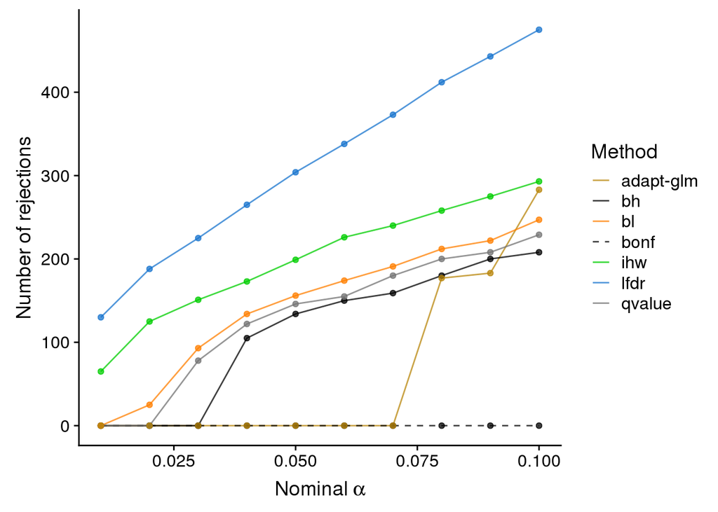

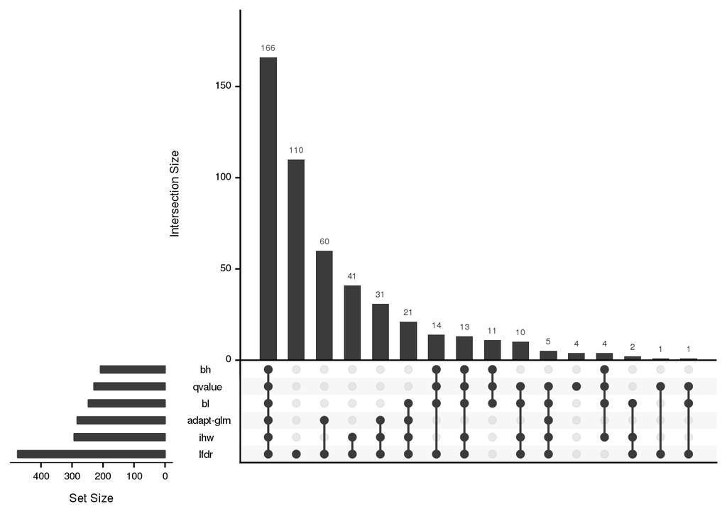

```r
plotFDRMethodsOverlap(sGSEA, alpha=0.1, supplementary=FALSE, order.by="freq", nsets=100)
```

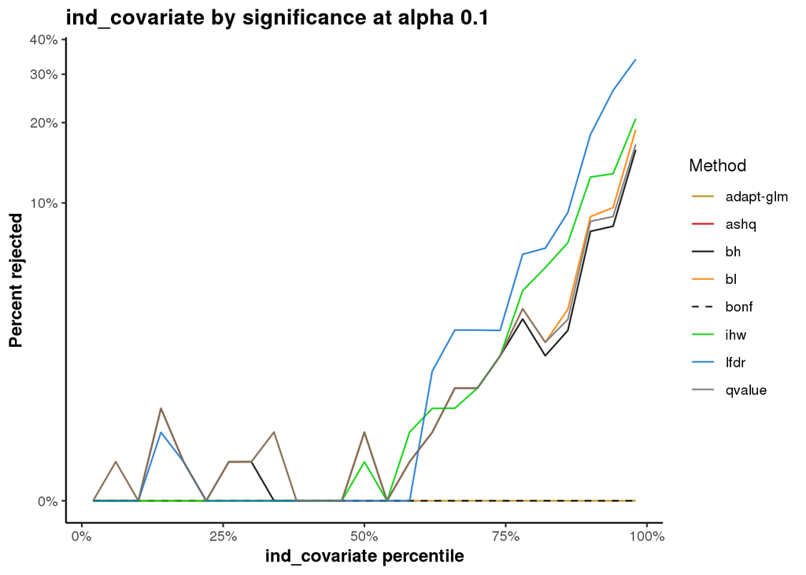

```r
covariateLinePlot(sGSEA, alpha = 0.1, covname = "ind_covariate", trans = "log1p")
```

### 4.4.2 Random

```r
assayNames(sGSEA_rand) <- "qvalue"
sGSEA_rand <- addDefaultMetrics(sGSEA_rand)
sGSEA_rand <- estimatePerformanceMetrics(sGSEA_rand, addColData=TRUE)
```

```r
rejections_scatter(sGSEA_rand, as_fraction=FALSE, supplementary=FALSE)
```

```
## Found already estimated performance metrics, replacing these
```

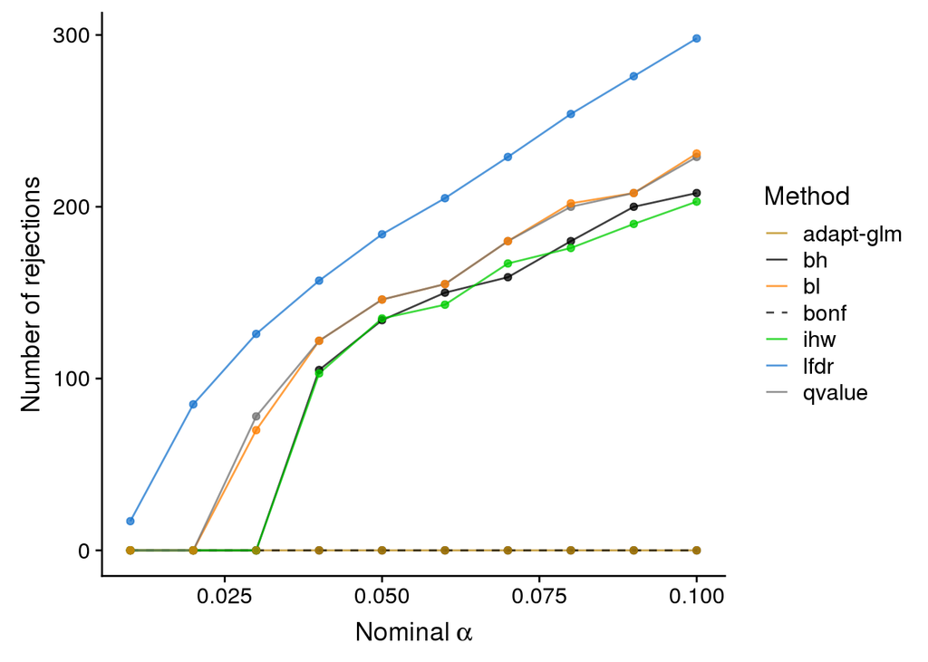

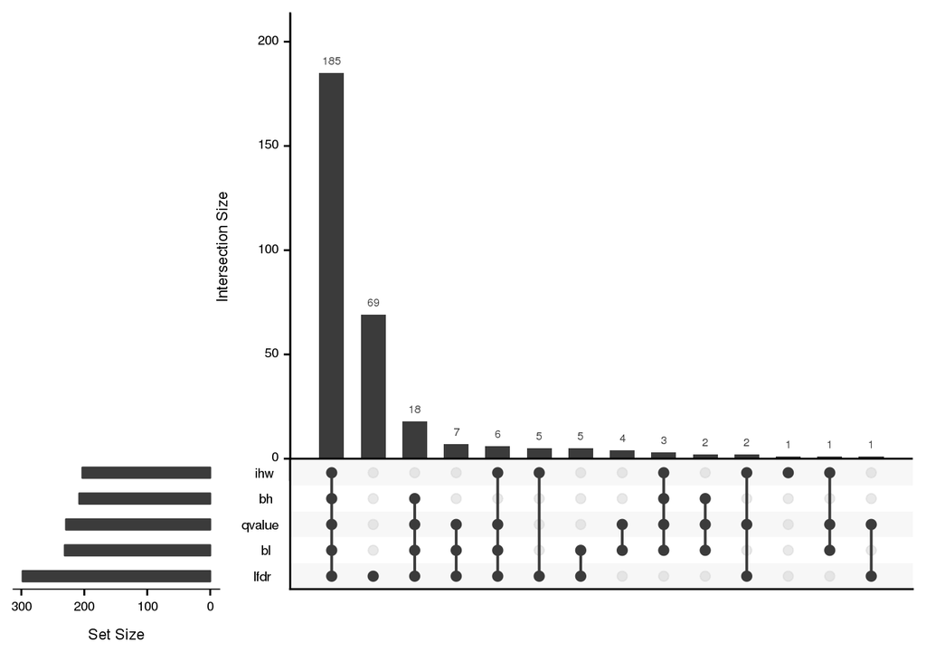

```r
plotFDRMethodsOverlap(sGSEA_rand, alpha=0.1, supplementary=FALSE, order.by="freq", nsets=100)
```

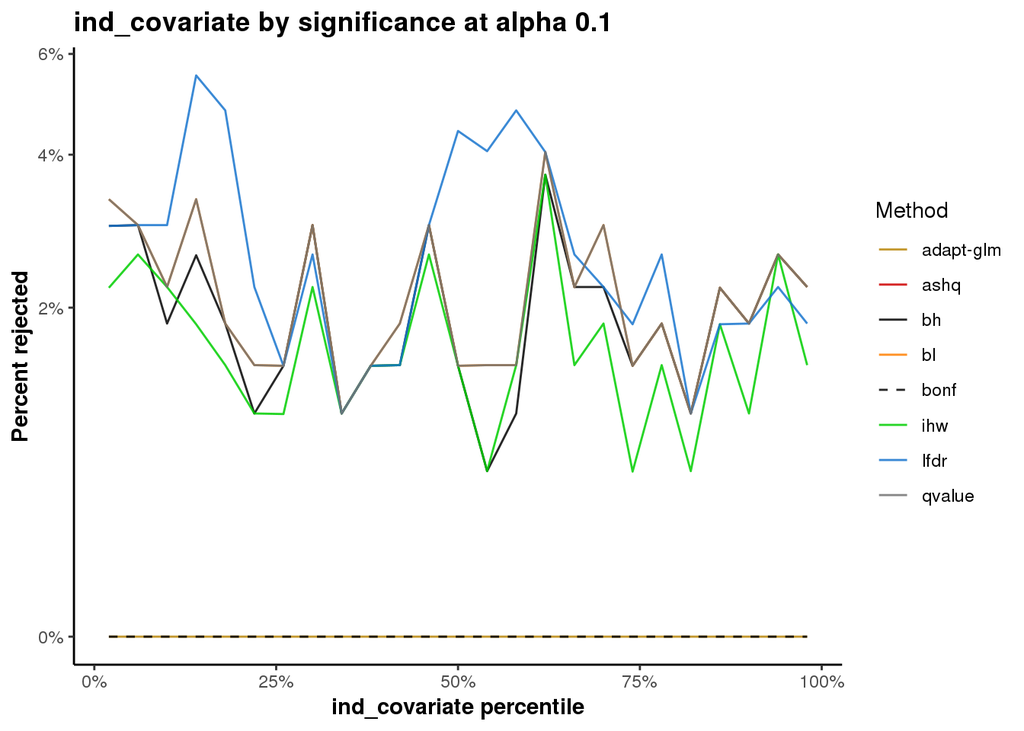

```r
covariateLinePlot(sGSEA_rand, alpha = 0.1, covname = "ind_covariate", trans = "log1p")
```

## 4.5 Covariate comparison

Here we compare the method ranks for the two covariates at alpha = 0.10.

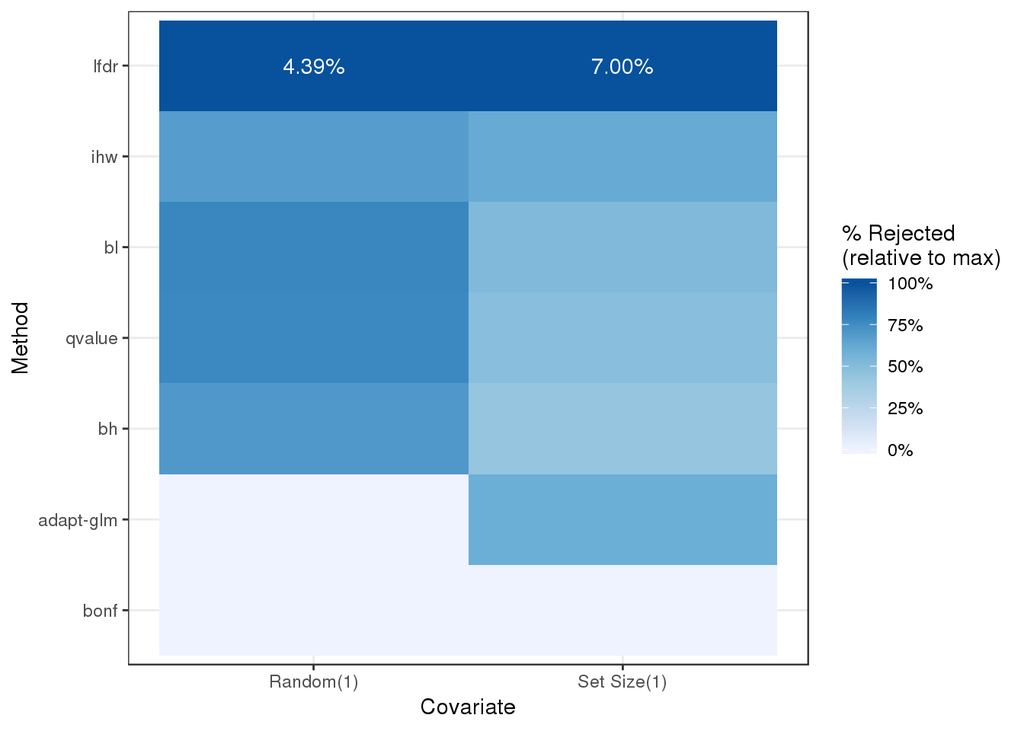

```r
plotMethodRanks(c(bench_file, bench_file_uninf),
                colLabels = c("Set Size", "Random"),
                alpha = 0.10, xlab = "Covariate",
                excludeMethods = NULL)
```